# BUSS6002 - Data Science in Business

#### Pre-Tutorial Checklist

1. Complete Tasks 1, 2 and 3 from Week 1
2. Download the “DirectMarketing.csv” file from Canvas
3. Attempt Week 2 tutorial up to but not including Exercise 1

# Tutorial 2 - Data Handling and Visualisation

## Libraries

For this tutorial you will need to use external libraries. Libraries are groups of useful functions for a particular task.

The `import` statement is used to make the library available in your code. For example to import the library called `pandas` you would use the following code

```python
import pandas as pd
```

### Getting Help

All these libraries have their own documentation available online. I suggest you become familiar with using the online documentation. For example here is the documentation for `pandas` https://pandas.pydata.org/pandas-docs/stable/

### Google is Your Friend

Googling "library function_name" e.g. "pandas read excel", is the quickest way to access the documentation.

# Data Handling - Pandas

### Documentation - General Pandas

https://pandas.pydata.org/pandas-docs/stable/

Pandas is a library for data manipulation. The key feature of Pandas is that the data structures it uses (a Dataframe) can hold multiple different data types. For example it can create an array with integers, strings and floating point numbers all at once. You could consider this capability as similar to an excel spreadsheet. Whereas you cannot mix and match data types in Python Lists or Numpy Arrays.

Pandas is already installed and available in Anaconda/Spyder. To begin using it we first import it as follows

```python
import pandas as pd
```

## Loading Data

We will look at an example of how to load an Excel file containing a dataset. The data set `"DirectMarketing.csv"` contains information on 1000 customers for the comany Direct Marketing (DM).

1. Download the `"DirectMarketing.csv"` file from Blackboard and place it in the same folder as your Python file or Jupyter Notebook.

[figure not shown]

1. We can load the file into Python and convert it to a Dataframe by

#### pandas.read_csv

https://pandas.pydata.org/pandas-docs/stable/reference/api/pandas.read_csv.html

Notice that the return value of `read_csv` is a DataFrame!

```python
marketing = pd.read_csv('DirectMarketing.csv')
```

# Pandas DataFrame

What is the marketing variable? We can check by using the `type` function.

```python
type(marketing)
```

```
pandas.core.frame.DataFrame
```

A DataFrame is a table of data, which means it has two dimensions: rows and columns. Usually observations are along the rows and attributes or features are along the columns.

## Inspecting Data

#### DataFrame.Head

https://pandas.pydata.org/pandas-docs/stable/reference/api/pandas.DataFrame.head.html

We can check the first 5 rows of the marketing Dataframe by using its head function.

```python
marketing.head()
```

|  | Age | Gender | OwnHome | Married | Location | Salary | Children | History | Catalogs | AmountSpent |
| --- | --- | --- | --- | --- | --- | --- | --- | --- | --- | --- |
| 0 | Old | Female | Own | Single | Far | 47500 | 0 | High | 6 | 755 |
| 1 | Middle | Male | Rent | Single | Close | 63600 | 0 | High | 6 | 1318 |
| 2 | Young | Female | Rent | Single | Close | 13500 | 0 | Low | 18 | 296 |
| 3 | Middle | Male | Own | Married | Close | 85600 | 1 | High | 18 | 2436 |
| 4 | Middle | Female | Own | Single | Close | 68400 | 0 | High | 12 | 1304 |

### Exercise 1 - Head and Tail

1. Can you show the first 10 rows of data?
2. Can you show the last 3 rows of data? (Use google to find the `tail` function)

### DataFrame.Info

https://pandas.pydata.org/pandas-docs/stable/reference/api/pandas.DataFrame.info.html

To see the full information about a dataframe including number of entries and datatypes use the info() function

```python
marketing.info()
```

```
<class 'pandas.core.frame.DataFrame'>
RangeIndex: 1000 entries, 0 to 999
Data columns (total 10 columns):
Age            1000 non-null object
Gender         1000 non-null object
OwnHome        1000 non-null object
Married        1000 non-null object
Location       1000 non-null object
Salary         1000 non-null int64
Children       1000 non-null int64
History        697 non-null object
Catalogs       1000 non-null int64
AmountSpent    1000 non-null int64
dtypes: int64(4), object(6)
memory usage: 78.2+ KB
```

### DataFrame.Describe

https://pandas.pydata.org/pandas-docs/stable/reference/api/pandas.DataFrame.describe.html

```python
marketing.describe()
```

|  | Salary | Children | Catalogs | AmountSpent |
| --- | --- | --- | --- | --- |
| count | 1000.000000 | 1000.00000 | 1000.000000 | 1000.000000 |
| mean | 56103.900000 | 0.93400 | 14.682000 | 1216.770000 |
| std | 30616.314826 | 1.05107 | 6.622895 | 961.068613 |
| min | 10100.000000 | 0.00000 | 6.000000 | 38.000000 |
| 25% | 29975.000000 | 0.00000 | 6.000000 | 488.250000 |
| 50% | 53700.000000 | 1.00000 | 12.000000 | 962.000000 |
| 75% | 77025.000000 | 2.00000 | 18.000000 | 1688.500000 |
| max | 168800.000000 | 3.00000 | 24.000000 | 6217.000000 |

# Pandas Series

A Series is a column of a Pandas DataFrame.

We can extract the column by putting a string of the column name inside the indexing brackets `[ ]`. For example if we want the column corresponding to the `Catalogs` variable we would do the following

```python
catalogs = marketing['Catalogs']
```

```python
type(catalogs)
```

```
pandas.core.series.Series
```

```python
catalogs.head()
```

```
0     6
1     6
2    18
3    18
4    12
Name: Catalogs, dtype: int64
```

```python
catalogs.describe()
```

```
count    1000.000000
mean       14.682000
std         6.622895
min         6.000000
25%         6.000000
50%        12.000000
75%        18.000000
max        24.000000
Name: Catalogs, dtype: float64
```

# Indexing and Slicing

Now you know how to create a DataFrame and extract a single column as a Series. Often we are interested in multiple variables or only certain rows from our data.

We can use Panda's indexing and slicing functions to extract subsections of data from a Dataframe.

You can index a Dataframe with two functions:

- loc, indexing by labels in the index ([documentation](https://pandas.pydata.org/pandas-docs/stable/reference/api/pandas.DataFrame.loc.html))
- iloc, indexing by physical position ([documentation](https://pandas.pydata.org/pandas-docs/version/0.17.0/generated/pandas.DataFrame.iloc.html))

A dataframe has a special column called the "index". This is a unique identifier for each row/observation in our data. This index is often numerical but can be a string or date etc.

[figure not shown]

Both loc and iloc use the square bracket index notation. We can specify the rows and columns we wish to index with the following syntax: `[ROWS, COLUMNS]`.

If we want every column or row we can use `:` in place of ROWS or COLUMNS. We can also specify a range by `start:end` or even just specifying a start or end point e.g. `start:` or `:end`

## Selecting Rows

For example let's extract the first 3 rows of the dataframe.

```python
# extract the first 3 rows of the dataframe
first_three_rows = marketing.iloc[0:3, :]
first_three_rows.head()
```

|  | Age | Gender | OwnHome | Married | Location | Salary | Children | History | Catalogs | AmountSpent |
| --- | --- | --- | --- | --- | --- | --- | --- | --- | --- | --- |
| 0 | Old | Female | Own | Single | Far | 47500 | 0 | High | 6 | 755 |
| 1 | Middle | Male | Rent | Single | Close | 63600 | 0 | High | 6 | 1318 |
| 2 | Young | Female | Rent | Single | Close | 13500 | 0 | Low | 18 | 296 |

As mentioned we do not need to specify the start point of this range e.g.

```python
first_three_rows = marketing.iloc[:3, :]
first_three_rows.head()
```

|  | Age | Gender | OwnHome | Married | Location | Salary | Children | History | Catalogs | AmountSpent |
| --- | --- | --- | --- | --- | --- | --- | --- | --- | --- | --- |
| 0 | Old | Female | Own | Single | Far | 47500 | 0 | High | 6 | 755 |
| 1 | Middle | Male | Rent | Single | Close | 63600 | 0 | High | 6 | 1318 |
| 2 | Young | Female | Rent | Single | Close | 13500 | 0 | Low | 18 | 296 |

## Selecting Columns

Columns are selected in exactly the same way

```python
columns = marketing.iloc[:, 2:5]
columns.head()
```

|  | OwnHome | Married | Location |
| --- | --- | --- | --- |
| 0 | Own | Single | Far |
| 1 | Rent | Single | Close |
| 2 | Rent | Single | Close |
| 3 | Own | Married | Close |
| 4 | Own | Single | Close |

## Selecting Rows and Columns

We can index columns much the same and even get a subset of columns and rows e.g.

```python
# Rows 0-3, Columns 5-10
subset = marketing.iloc[:3, 5:10]
subset.head()
```

|  | Salary | Children | History | Catalogs | AmountSpent |
| --- | --- | --- | --- | --- | --- |
| 0 | 47500 | 0 | High | 6 | 755 |
| 1 | 63600 | 0 | High | 6 | 1318 |
| 2 | 13500 | 0 | Low | 18 | 296 |

If you would like to index columns or rows that are not sequential then you can use an array of index values e.g. let's grab columns 0, 1, 2, 5 and 9.

```python
column_index = [0, 1, 2, 5, 9]

subset = marketing.iloc[:, column_index]

subset.head()
```

|  | Age | Gender | OwnHome | Salary | AmountSpent |
| --- | --- | --- | --- | --- | --- |
| 0 | Old | Female | Own | 47500 | 755 |
| 1 | Middle | Male | Rent | 63600 | 1318 |
| 2 | Young | Female | Rent | 13500 | 296 |
| 3 | Middle | Male | Own | 85600 | 2436 |
| 4 | Middle | Female | Own | 68400 | 1304 |

## Indexing by Name

You have already seen one example of indexing by name

```
catalogs = marketing['Catalogs']
```

Where possible I suggest that you index by name. It makes your code more readable!

### Multiple Columns

By default if you just use the indexing brackets `[ ]` pandas will assume you are referring to the DataFrame columns. You can then pass in a list of column names.

For example if we are interested in the columns `Age`, `Gender` and `AmountSpent` we can do

```python
column_names = ['Age', 'Gender', 'AmountSpent']
subset = marketing[column_names]

subset.head()
```

|  | Age | Gender | AmountSpent |
| --- | --- | --- | --- |
| 0 | Old | Female | 755 |
| 1 | Middle | Male | 1318 |
| 2 | Young | Female | 296 |
| 3 | Middle | Male | 2436 |
| 4 | Middle | Female | 1304 |

### Exercise 2 - Nesting

In the above column example we used the following two lines of code to slice the data

```
column_names = ['Age', 'Gender', 'AmountSpent']
subset = marketing[column_names]
```

Can you think of a way to do this in one line of code?

## Statistics

### Mean

https://pandas.pydata.org/pandas-docs/stable/reference/api/pandas.DataFrame.mean.html

Computing the mean of a DataFrame or Series is straightfoward

```python
# Notice that only numeric variables are included
marketing.mean(axis = 0)
```

```
Salary         56103.900
Children           0.934
Catalogs          14.682
AmountSpent     1216.770
dtype: float64
```

```python
# We can also compute the mean of a series
marketing['Salary'].mean()
```

```
56103.9
```

### Standard Deviation and Variance

- https://pandas.pydata.org/pandas-docs/stable/reference/api/pandas.DataFrame.std.html
- https://pandas.pydata.org/pandas-docs/stable/reference/api/pandas.DataFrame.var.html

Standard Deviation and Variance functions work exactly the same as the mean function and variants exist for both DataFrame and Series.

### Exercise 3 - Statistics

1. Can you calculate the variance of the `Age` variable?
2. What is the standard deviation of `AmountSpent`?

# Visualisation - pyplot

### pyplot

https://matplotlib.org/api/pyplot_api.html

pyplot is a library for visualisation. It provides many plot types such as:

- scatter
- line
- histogram
- bar chart
- box plot
- pie chart
- and many more!

The pyplot syntax is borrowed from MATLAB's plotting functions. So if you know how to plot with MATLAB you can plot with pyplot and vice-versa!

**Note:** pyplot is a sub-library of matplotlib. So to import it we use the following command

```python
%matplotlib inline
# 'matplotlib inline' is a special command that tells Jupyter
# to plot everything immediately after each cell

import matplotlib.pyplot as plt
```

## Scatter Plot

### scatter

https://matplotlib.org/api/_as_gen/matplotlib.pyplot.scatter.html

### Example

A scatter plot draws a set of points on a two-dimensional grid. For example let's create a scatter plot of points

```
(2, 3), (4, 8), (10, 10)
```

where `(2, 3)` means `(x=2, y=3)`.

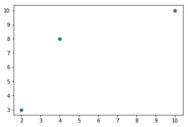

```python
x_values = [2, 4, 10]
y_values = [3, 8, 10]

plt.scatter(x_values, y_values)

plt.show()
```

### Scatter from Data

Now let's scatter from some real data to see if there is a visible relationship between the variables.

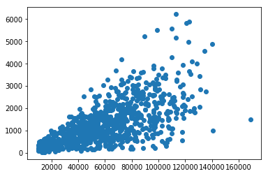

```python
salary = marketing['Salary']
spent = marketing['AmountSpent']

plt.scatter(salary, spent)

plt.show()
```

## Pretty Plots

So far our plot tells us a lot about the relationship between salary and customer spending. However if we showed this plot to someone else it would be useless!

It is very important to tidy up your plots so that they are meaningful to others. Lets try again and add:

- title
- axis labels
- legend
- transparency

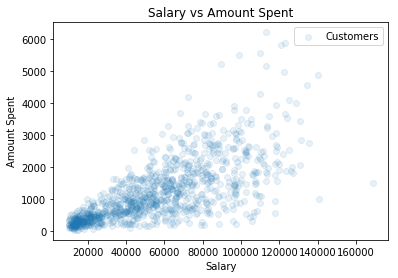

```python
salary = marketing['Salary']
spent = marketing['AmountSpent']

plt.scatter(salary, spent, alpha = 0.1, label = "Customers")

# Set the x-axis label
plt.xlabel("Salary")
# Set the y-axis label
plt.ylabel("Amount Spent")
# Set the title
plt.title("Salary vs Amount Spent")
# Add the legend
plt.legend()

plt.show()
```

### Exercise 4 - Reading Documentation

1. What is the default marker style for the scatter function? Can you draw it?
2. Can you change the above plot to use square markers?

## Line Plot

### plot (Line Plot)

https://matplotlib.org/api/_as_gen/matplotlib.pyplot.plot.html

### Example

Line plotting works in much the same way as scatter plots except the dots are automatically joined to form a single line. Let's create a line plot that joins the following points:

```
(1, 1), (2, 5), (6, 3), (7, 6)
```

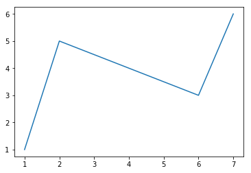

```python
x_values = [1, 2, 6, 7]
y_values = [1, 5, 3, 6]

plt.plot(x_values, y_values)

plt.show()
```

### Evenly Spaced Points

If you do not provide the plot function with x-values it assumes the input is for the y-axis and then evenly spaces each point on the x-axis.

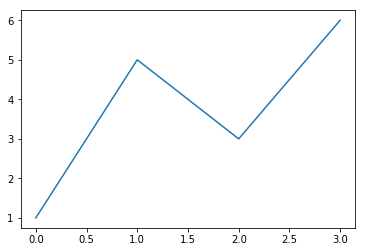

```python
y_values = [1, 5, 3, 6]

plt.plot(y_values)

plt.show()
```